# 52414: Lab 2

Or Zuk

May 19, 2020

## *Lab 2: Visualization Through `ggplot`*

**Contents**:

- Q0. Submission Instructions
- Q1. Basic Statistics (25 pt)
- Q2. Scouting Report (25 pt)
- Q3. Model Building (30 pt)
- Q4. Fix Problematic Plots (10 pt)
- Q5. Open Question (10 pt)

### Q0.Submission Instructions

This lab will be submitted in pairs using GitHub (if you don’t have a pair, please contact us).  
Please follow the steps in the [GitHub-Classroom Lab 2](https://classroom.github.com/g/6_Wy5z44) to create your group’s Lab 2 repository.  
**Important: your team’s name must be `FamilyName1_Name1_and_FamilyName2_Name2`**.  
You can collaborate with your partner using the git environment; You can either make commits straight to master, or create individual branches (recommended). However, once done, be sure to merge your branches to master - you will be graded using the most recent *master* version - your last push and merge before the deadline.  
**Please do not open/review other peoples’ repositories - we will be notified by GitHub if you do.**

Your final push should include this Rmd file (with your answers) together with the html file that is outputted automatically by knitr when you knit the Rmd. Anything else will be disregarded. In addition, please adhere to the following file format:  
`Lab_2_FamilyName1_Name1_and_FamilyName2_Name2.Rmd/html`

Some questions may require data wrangling and manipulation which you need to decide on.  
In some graphs you may need to change the graph limits. If you do so, please include the outlier points you have removed in a separate table.

Show numbers in plots/tables using standard digits and not scientific display. That is: 90000000 and not 9e+06.  
Round numbers to at most 3 digits after the dot - that is, 9.456 and not 9.45581451044

The required libraries are listed below the instructions. You are allowed to add additional libraries if you want. If you do so, *please explain what libraries you’ve added, and what is each new library used for*.

#### Background:

You’ve been hired as a data analyst at the football (soccer) club Hapoel London. Since this is a small and under-funded club, you will not have access to real-football data, but to data from the football computer game fifa18. Your job is to analyze this dataset and extract meaningful insights from the data in order to help your club make better decisions.

#### Data File:

You will load and analyze the fifa18 football dataset file called “fifa_data.csv”.  
The dataset contains detailed information about each player in the game, including: names, age, nationality, overall ability, estimated potential ability, current club and league, market value, salary (wage), ability at different football skills (also called ‘attributes’, e.g. Ball.control, Sprint.speed …), ability to play at different position in the game (CF, CM, …) and the preferred positions of the player.

Required Libraries:

```
## ### Welcome to rworldmap ###
```

```
## For a short introduction type :   vignette('rworldmap')
```

## Q1. Basic Statistics (25 pt)

First, you are requested to load the fifa18 dataset and find and display general information about the players.

1. Make a plot showing the age distribution of all players.
2. Make a plot comparing the *overall* ability of players in different leagues (‘League’). Describe which leagues have especially good/bad players.
3. Make a plot showing the density of players’ salary (‘Wage’) distribution.  
   Next, make a separate plot showing the density distribution of the *log* of players’ salary.  
   Which of the two visualizations is better? how skewed are the distributions? do they have fat tails? which is better described by a Normal distribution? explain.
4. Are the top-10 players with the highest value also the top-10 best players in terms of *overall* ability? Show tables for both and compare.  
   Who is the best player not in the top-10 valued players?
5. Show a table of the ten *best* and ten *worst* teams in terms of *average* player overall ability.

Loading the data + Q1 Answers: a. Make a plot showing the age distribution of all players.

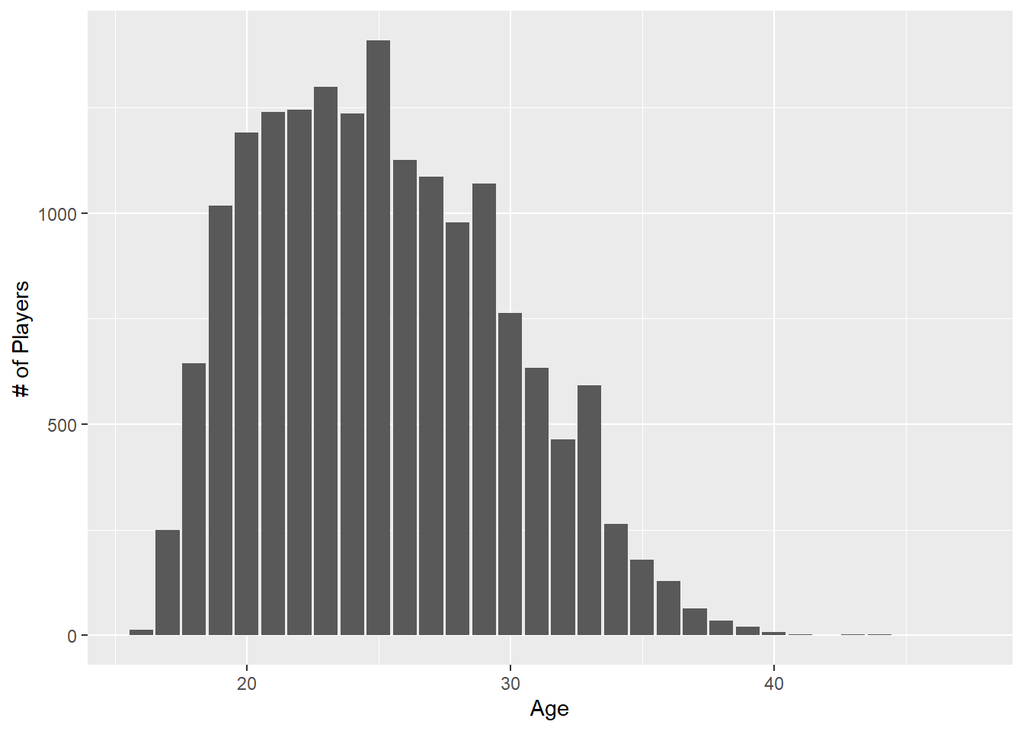

```r
fifa_players <- data.frame(read.csv(url("https://raw.githubusercontent.com/DataScienceHU/DataAnalysisR_2020/master/data/fifa_data.csv")))
# Pre-processing:
for (i in c(3,6,7,10:71)) {
  fifa_players[,i]<-as.numeric((fifa_players[,i]))
}
fifa<-na.omit(fifa_players)
fifa_players<-fifa
fifa_players_info<-fifa[,c(1:11)] # players general info
fifa_players_attribures<-fifa[,c(1,12:45, 6)] # players different skills. Add overall
fifa_players_positions<-fifa[,c(1,46:72,6)] # players ability at different positions . Add overall

#a - Age Distribution

ggplot(data = fifa_players,aes(x=Age))+geom_bar()+xlab("Age")+ylab("# of Players")
```

The highest distribution is within age 25 and it drops immidiately afterwords. There are several players in the late 40s with is surprising.

2. Make a plot comparing the *overall* ability of players in different leagues (‘League’). Describe which leagues have especially good/bad players.

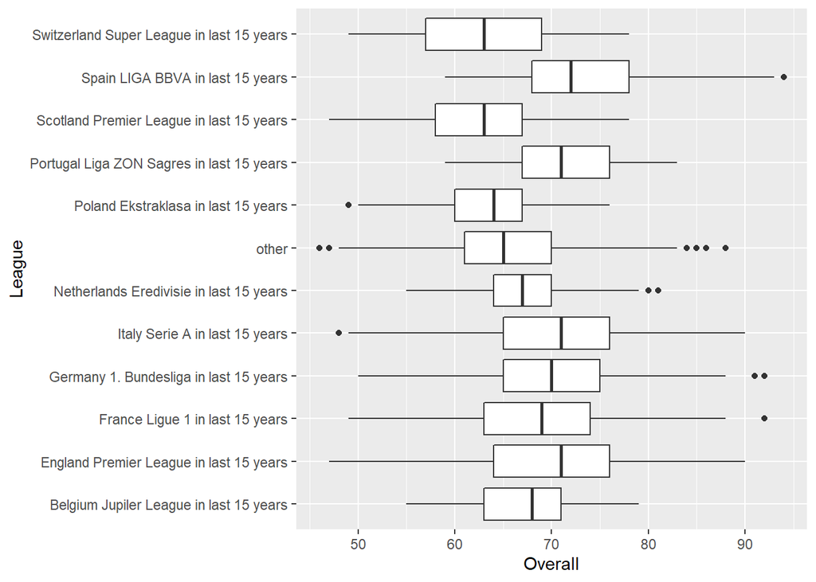

```r
#b

ggplot(data = fifa_players,aes(x=League,y = Overall))+geom_boxplot()+coord_flip()
```

Spain, Portugal Premier League and serie A have especially good players. Both Switzerland and Scotland leagues have especially bad players.

3. Make a plot showing the density of players’ salary (‘Wage’) distribution.  
   Next, make a separate plot showing the density distribution of the *log* of players’ salary.  
   Which of the two visualizations is better? how skewed are the distributions? do they have fat tails? which is better described by a Normal distribution? explain.

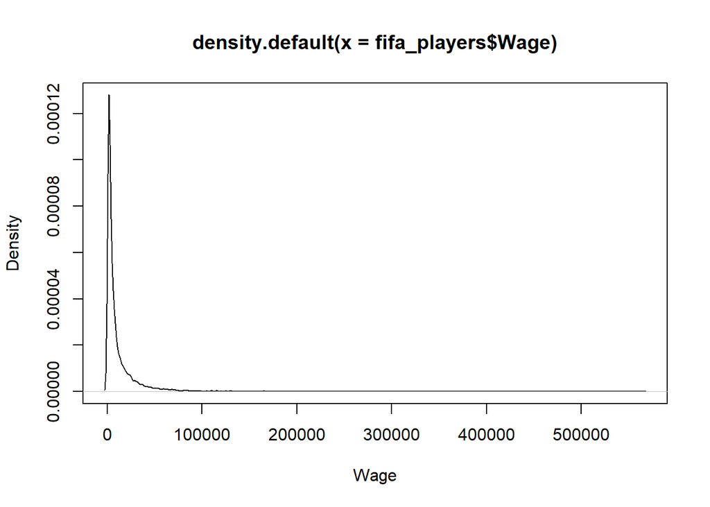

```r
#c

d<-density(fifa_players$Wage)
plot(d, xlab="Wage")
```

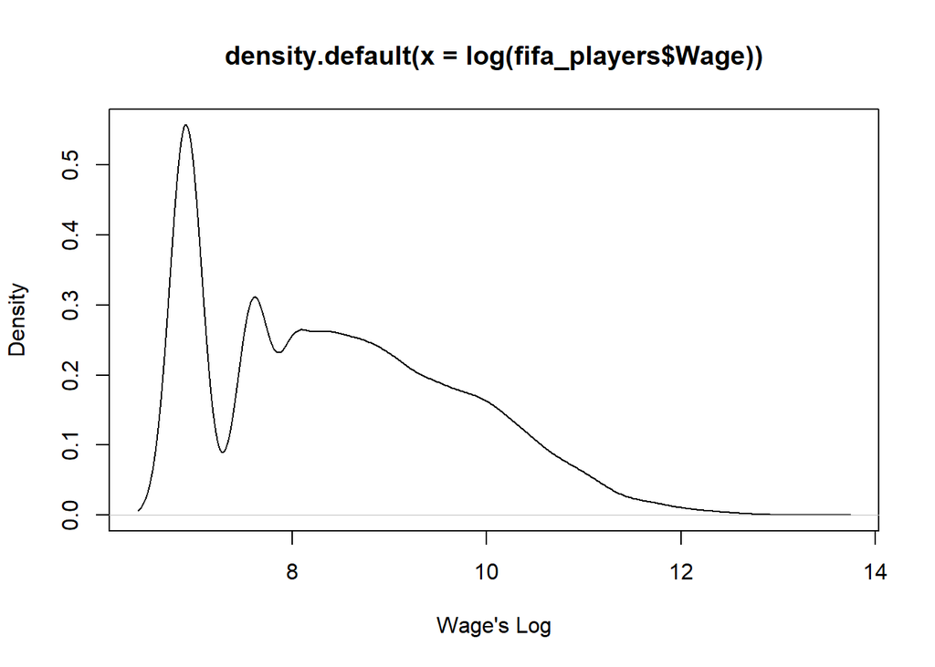

```r
#log of the salaries

d2<-density(log(fifa_players$Wage))
plot(d2, xlab="Wage's Log")
```

```r
#Skeweness&Fat Tails
wage <- fifa_players %>% select(Wage) %>% subset(Wage>0) # wage with no zeros, otherwise log wont be defined
wage<-wage$Wage
skewness(wage)
```

```
## [1] 6.987
```

```r
skewness(log(wage))
```

```
## [1] 0.4743
```

```r
kurtosis(wage)
```

```
## [1] 87.56
```

```r
kurtosis(log(wage))
```

```
## [1] -0.572
```

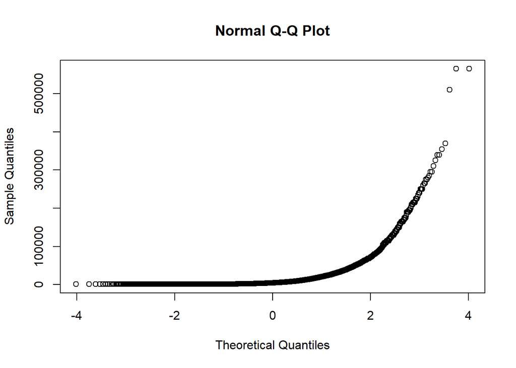

```r
# plotting a qqplot to see which one looks more normal.

qqnorm(wage)
```

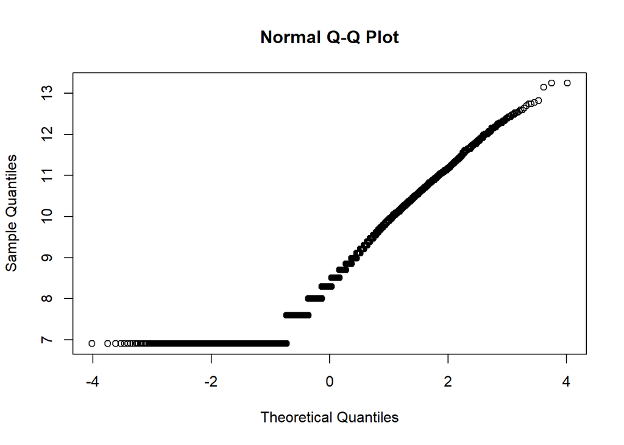

```r
qqnorm(log(wage))
```

4. Are the top-10 players with the highest value also the top-10 best players in terms of *overall* ability? Show tables for both and compare.  
   Who is the best player not in the top-10 valued players?

```r
#d

top_10_players_by_overall<-fifa_players %>% select(Name, Overall) %>% top_n(Overall, n=10)

# top ten players by overall
arrange(top_10_players_by_overall,desc(Overall))
```

```
##                 Name Overall
## 1  Cristiano Ronaldo      94
## 2           L. Messi      93
## 3             Neymar      92
## 4           M. Neuer      92
## 5         L. SuÃ¡rez      92
## 6     R. Lewandowski      91
## 7          E. Hazard      90
## 8             De Gea      90
## 9        G. HiguaÃn      90
## 10          T. Kroos      90
## 11      Sergio Ramos      90
```

```r
top_10_players_by_wage<-fifa_players %>% select(Name, Wage) %>% top_n(Wage, n=10)

# top 10 players by wage
arrange(top_10_players_by_wage,desc(Wage))
```

```
##                 Name   Wage
## 1           L. Messi 565000
## 2  Cristiano Ronaldo 565000
## 3         L. SuÃ¡rez 510000
## 4            G. Bale 370000
## 5     R. Lewandowski 355000
## 6           T. Kroos 340000
## 7         L. ModriÄ‡ 340000
## 8         S. AgÃ¼ero 325000
## 9       Sergio Ramos 310000
## 10         E. Hazard 295000
## 11        K. Benzema 295000
```

5. Show a table of the ten *best* and ten *worst* teams in terms of *average* player overall ability.

```r
#e

teams_avg_ability<-fifa_players %>% select(Club, Overall) %>% group_by(Club) %>% summarise(Overall=mean(Overall))

#ten best
head(arrange(teams_avg_ability,desc(Overall)),10)
```

```
## # A tibble: 10 x 2
##    Club                Overall
##    <chr>                 <dbl>
##  1 FC Barcelona           82.6
##  2 Juventus               81.5
##  3 Real Madrid CF         81.0
##  4 FC Bayern Munich       80.2
##  5 Paris Saint-Germain    78.0
##  6 Napoli                 77.6
##  7 Manchester United      77.5
##  8 Roma                   77.0
##  9 Sevilla FC             77.0
## 10 Inter                  76.7
```

```r
# ten worst
head(arrange(teams_avg_ability,Overall),10)
```

```
## # A tibble: 10 x 2
##    Club            Overall
##    <chr>             <dbl>
##  1 Galway United      54.1
##  2 Drogheda United    54.8
##  3 Finn Harps         55
##  4 Limerick FC        55.5
##  5 Bohemian FC        55.8
##  6 Sligo Rovers       56.1
##  7 Bray Wanderers     56.2
##  8 Crewe Alexandra    56.3
##  9 FC HelsingÃ¸r      56.6
## 10 Derry City         56.8
```

PLEASE ADD YOUR SOLUTION BELOW, WITH A CLEAR SEPARATION BETWEEN THE PARTS!

## Q2. Scouting Report (25 pt)

You are in charge of the scouting division. The goal of this division is to follow players’ potential and overall ability, and identify undervalued players - that is, players whose current value is lower compared to what would be expected based on their predicted future ability.

1. Your boss wants to fly abroad to recruit promising players. Use the *rworldmap* package to display the world map and color each country based on the *total number of players* from this nationality.
2. Quantity may not guarantee quality. Repeat the above analysis but this time display a world map where each country is colored by the *average overall quality* of players. Find an under-represented country you’d recommend to travel to (i.e. a country with few players with high overall average quality).
3. Show the *average overall* ability by *age* of all players, for players 35 years old or younger
4. Make a graph showing the *average difference* between a player’s overall ability to potential ability as a function of age, up to age 35. At what ages should we expect to find players for future development based on this graph?
5. We are seeking young (age <=21) players with high Overall ability (>85). Show a scatter plot of these players comparing their *Potential* ability (y-axis) and current salary (*Wage*, x-axis). Prepare a table showing the 10 most-undervalued players, i.e. currently lowest payed compared to their potential. Calculate for each of them what is a fair salary matching their potential that you would offer to lure them away from their current club and show it in the table.

PLEASE ADD YOUR SOLUTION BELOW, WITH A CLEAR SEPARATION BETWEEN THE PARTS!

Q2 answers:

Your boss wants to fly abroad to recruit promising players. Use the *rworldmap* package to display the world map and color each country based on the *total number of players* from this nationality.

```r
#a

countries_and_count<-fifa_players %>% select(Nationality, Name) %>% group_by(Nationality) %>% summarise(num_of_players=n_distinct(Name))

countries_and_count <- joinCountryData2Map(dF = countries_and_count, joinCode = "NAME", nameJoinColumn = "Nationality",verbose=FALSE)
```

```
## 133 codes from your data successfully matched countries in the map
## 4 codes from your data failed to match with a country code in the map
## 110 codes from the map weren't represented in your data
```

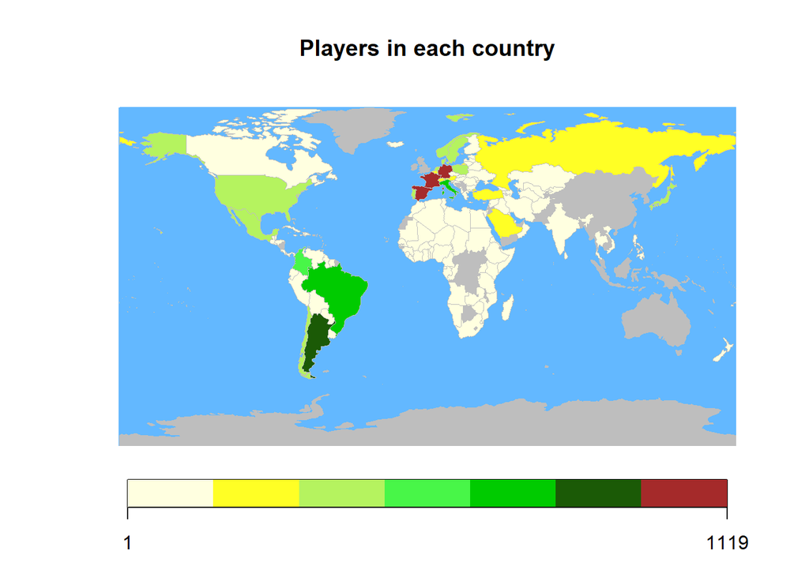

```r
mapCountryData(mapToPlot = countries_and_count, nameColumnToPlot = "num_of_players"
               ,catMethod = "fixedWidth",colourPalette = c("light yellow","yellow","light green","green"
                , "dark green","brown") ,oceanCol = "steelblue1", missingCountryCol = "gray",
               mapTitle = "Players in each country", aspect = "variable")
```

Quantity may not guarantee quality. Repeat the above analysis but this time display a world map where each country is colored by the *average overall quality* of players. Find an under-represented country you’d recommend to travel to (i.e. a country with few players with high overall average quality).

```r
#b

countries_and_means<-fifa_players %>% select(Nationality, Overall) %>% group_by(Nationality) %>% summarise(mean_overall=mean(Overall))

countries_and_means <- joinCountryData2Map(dF = countries_and_means, joinCode = "NAME", nameJoinColumn = "Nationality",verbose=FALSE)
```

```
## 133 codes from your data successfully matched countries in the map
## 4 codes from your data failed to match with a country code in the map
## 110 codes from the map weren't represented in your data
```

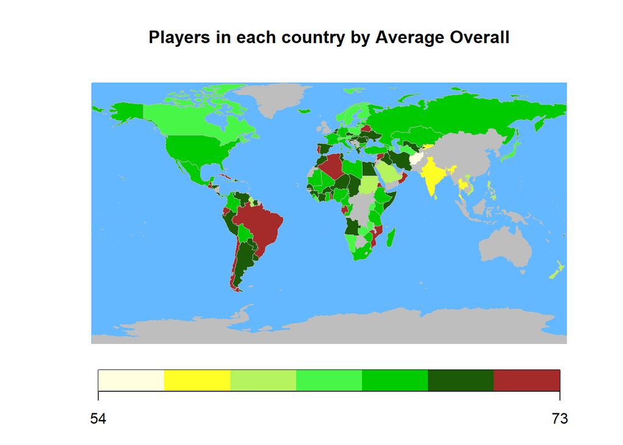

```r
mapCountryData(mapToPlot = countries_and_means, nameColumnToPlot = "mean_overall"
               ,catMethod = "fixedWidth",colourPalette = c("light yellow","yellow","light green","green"
                , "dark green","brown") ,oceanCol = "steelblue1", missingCountryCol = "gray",
               mapTitle = "Players in each country by Average Overall", aspect = "variable")
```

Solution: Algeria and Egypt are under represented countries because they doesnt have a lot of players but their overall rate is relatively high